# Stage 06b: Genotyping results

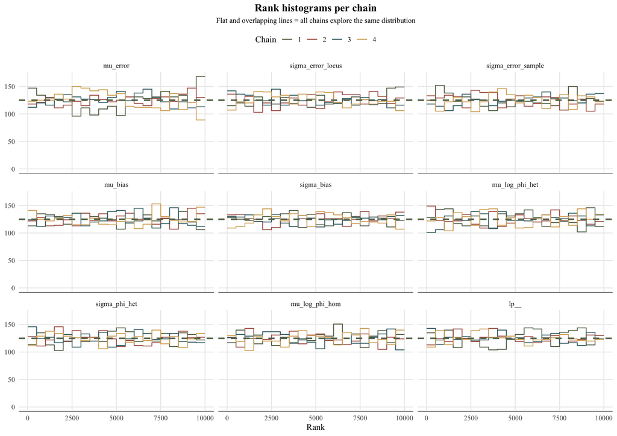

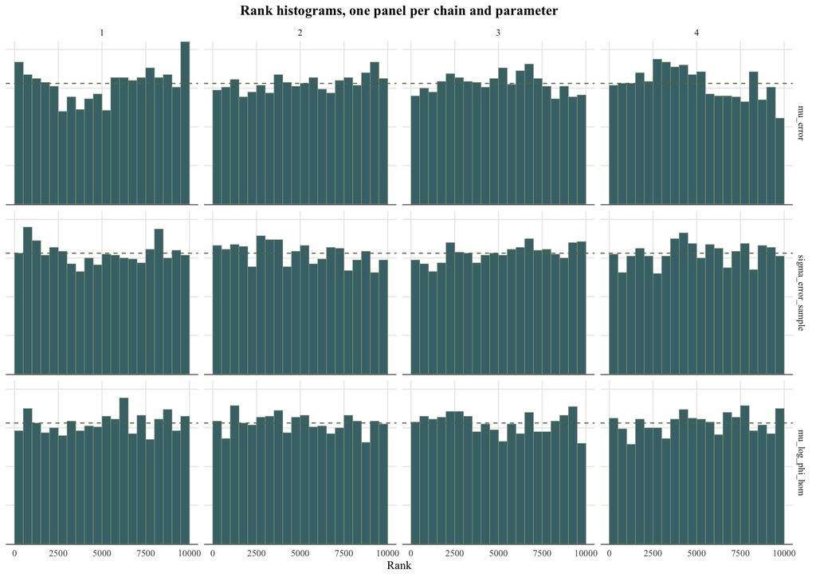

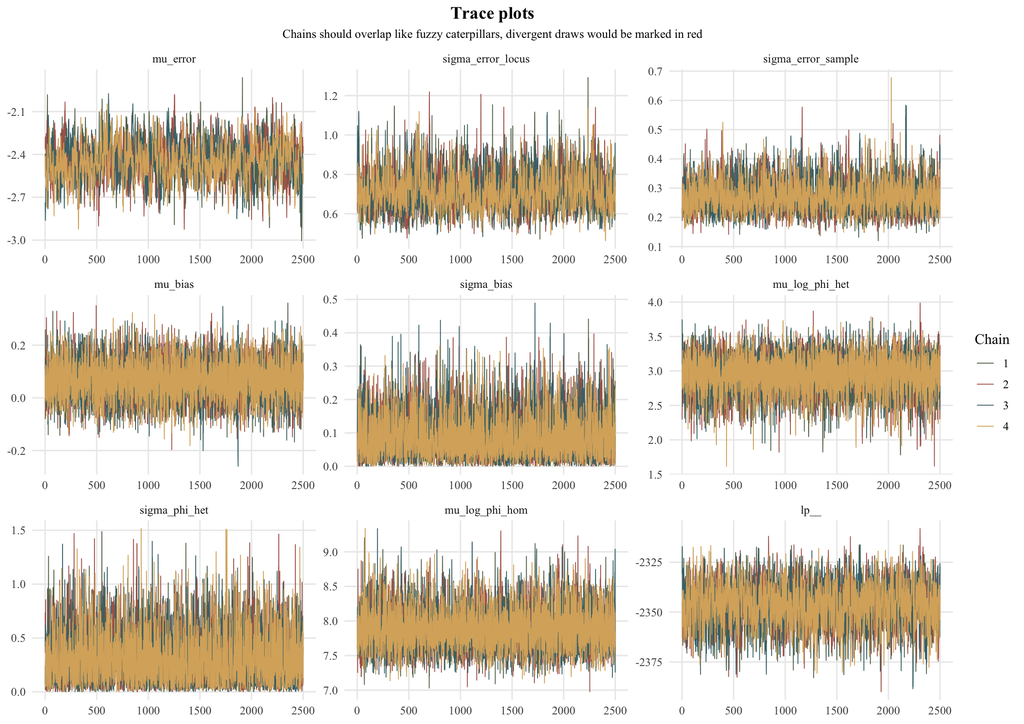

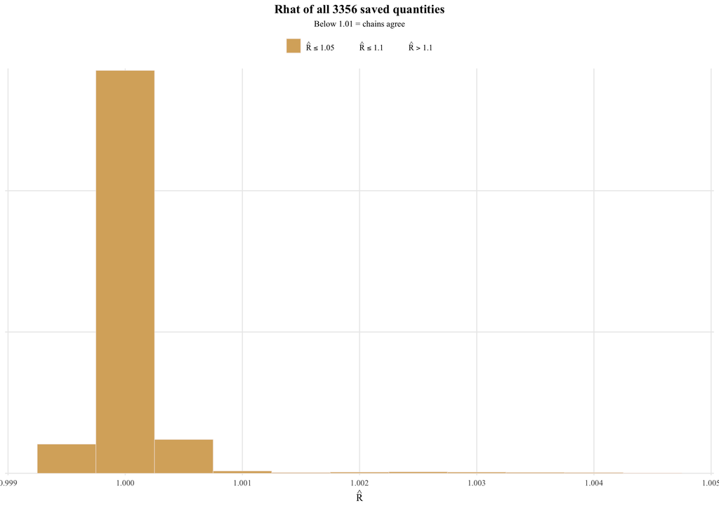

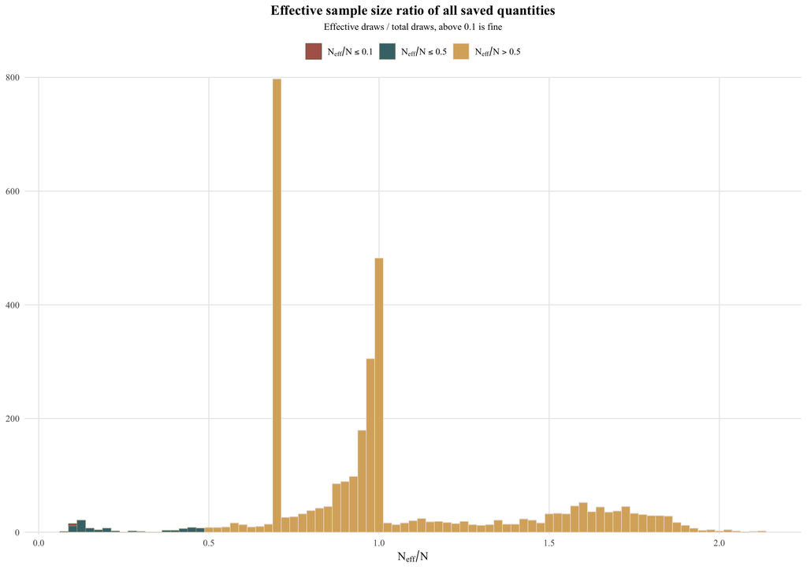

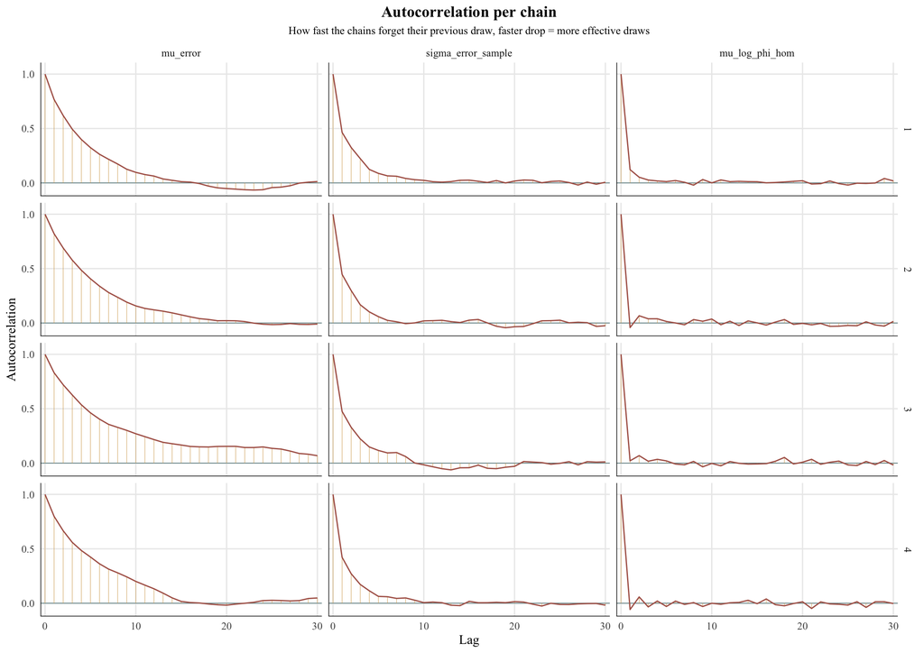

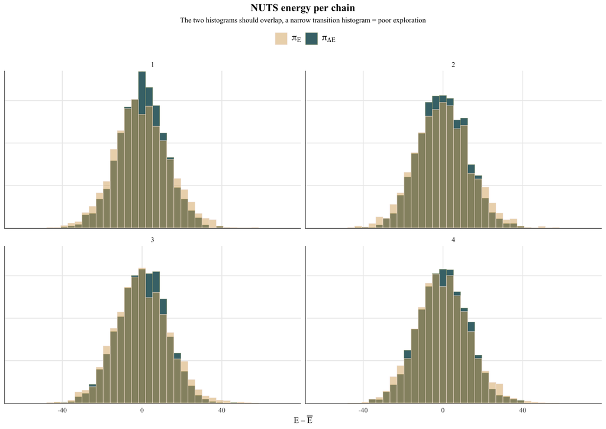

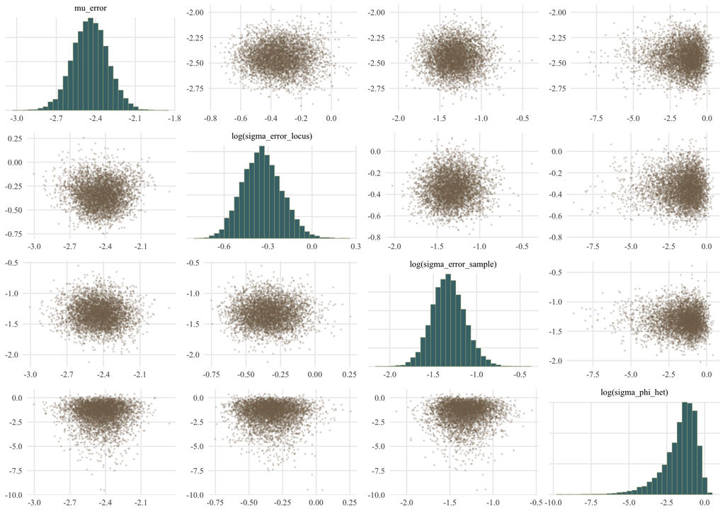

```r
stan_diagnostics_folder <- file.path(stan_graphics_folder, "Stan_Diagnostics_Plots")
dir.create(stan_diagnostics_folder, showWarnings = FALSE, recursive = TRUE)

color_scheme_set(c("#D9AF6B", "#F1E4DB", "#467378", "#9AA582", "#AF6458", "#657359"))
bayesplot_theme_set(theme_minimal(base_family = plot_font, base_size = 12) +
                      theme(plot.title = element_text(face = "bold", hjust = 0.5),
                            plot.subtitle = element_text(hjust = 0.5, size = 10),
                            legend.position = "top",
                            panel.grid.minor = element_blank()))

# Which mdoel parameters to plot
phi_hom_parameter <- intersect(c("phi_hom", "mu_log_phi_hom"), fit_hier@model_pars)[1] # list of the parameters
diagnostic_pars <- c("mu_error", # typical sequencing error rate (logit scale)
                     "sigma_error_locus", # how much error rate differs between loci
                     "sigma_error_sample", # between samples
                     "mu_bias", # typical allele balance in HT (logit scale, 0 = 50/50)
                     "sigma_bias", # how much allele balance differs between loci
                     "mu_log_phi_het", # typical overdispersion in HT (log scale)
                     "sigma_phi_het", # how much it differs between samples
                     phi_hom_parameter, # overdispersion in HM  (either shared, locus, sample or locussample)
                     "lp__") # log posterior, how well the parameters fit the data and priors
slow_mixing_pars <- c("mu_error", "sigma_error_sample", phi_hom_parameter) # the three shown in the rank histogram and autocorrelation plots
posterior_array_hier <- as.array(fit_hier, pars = diagnostic_pars) # draws*chains*parameters
nuts_hier <- nuts_params(fit_hier) # divergences, tree depth and energy of every draw

# Rhat of every parameter and effective sample size ratio of every parameter (how many independent draws are my draws worth)
rhat_hier <- rhat(fit_hier) # measures if the chains agree with each other
neff_ratio_hier <- neff_ratio(fit_hier) # shouldnt be belowe 0.1

# Plots made inside a list so it can later be used inside for loop, i can get rid of a lot of unnecessary ggsave lines for all the plots
stan_diagnostic_plots <- list(
  rank_overlay = mcmc_rank_overlay(posterior_array_hier, ref_line = TRUE, facet_args = list(ncol = 3)) +
    labs(title = "Rank histograms per chain",
         subtitle = "Flat and overlapping lines = all chains explore the same distribution"),
  rank_hist = mcmc_rank_hist(posterior_array_hier, pars = slow_mixing_pars, ref_line = TRUE) +
    labs(title = "Rank histograms, one panel per chain and parameter"),
  trace = mcmc_trace(posterior_array_hier, np = nuts_hier, facet_args = list(ncol = 3)) +
    labs(title = "Trace plots", subtitle = "Chains should overlap like fuzzy caterpillars, divergent draws would be marked in red"),
  rhat = mcmc_rhat_hist(rhat_hier[is.finite(rhat_hier)], binwidth = 0.0005) +
    labs(title = sprintf("Rhat of all %d saved quantities", sum(is.finite(rhat_hier))), subtitle = "Below 1.01 = chains agree"),
  neff = mcmc_neff_hist(neff_ratio_hier[is.finite(neff_ratio_hier)], binwidth = 0.025) +
    labs(title = "Effective sample size ratio of all saved quantities", subtitle = "Effective draws / total draws, above 0.1 is fine"),
  autocorrelation = mcmc_acf(posterior_array_hier, pars = slow_mixing_pars, lags = 30) +
    labs(title = "Autocorrelation per chain", subtitle = "How fast the chains forget their previous draw, faster drop = more effective draws"),
  energy = mcmc_nuts_energy(nuts_hier) +
    labs(title = "NUTS energy per chain", subtitle = "The two histograms should overlap, a narrow transition histogram = poor exploration"),
  pairs = mcmc_pairs(posterior_array_hier, pars = c("mu_error", "sigma_error_locus", "sigma_error_sample", "sigma_phi_het"),
                     transformations = list(sigma_error_locus = "log", sigma_error_sample = "log", sigma_phi_het = "log"),
                     np = nuts_hier, off_diag_args = list(size = 0.4, alpha = 0.2),
                     diag_args = list(bins = 40)))
suppressMessages(for (plot_name in names(stan_diagnostic_plots)) {
  print(stan_diagnostic_plots[[plot_name]])
  ggsave(file.path(stan_diagnostics_folder, paste0("diagnostics_", plot_name, ".png")), stan_diagnostic_plots[[plot_name]],
         width = 11.69, height = 8.27, dpi = 300, bg = "white")
  ggsave(file.path(stan_diagnostics_folder, paste0("diagnostics_", plot_name, ".pdf")), stan_diagnostic_plots[[plot_name]],
         width = 11.69, height = 8.27, device = cairo_pdf)
})
```

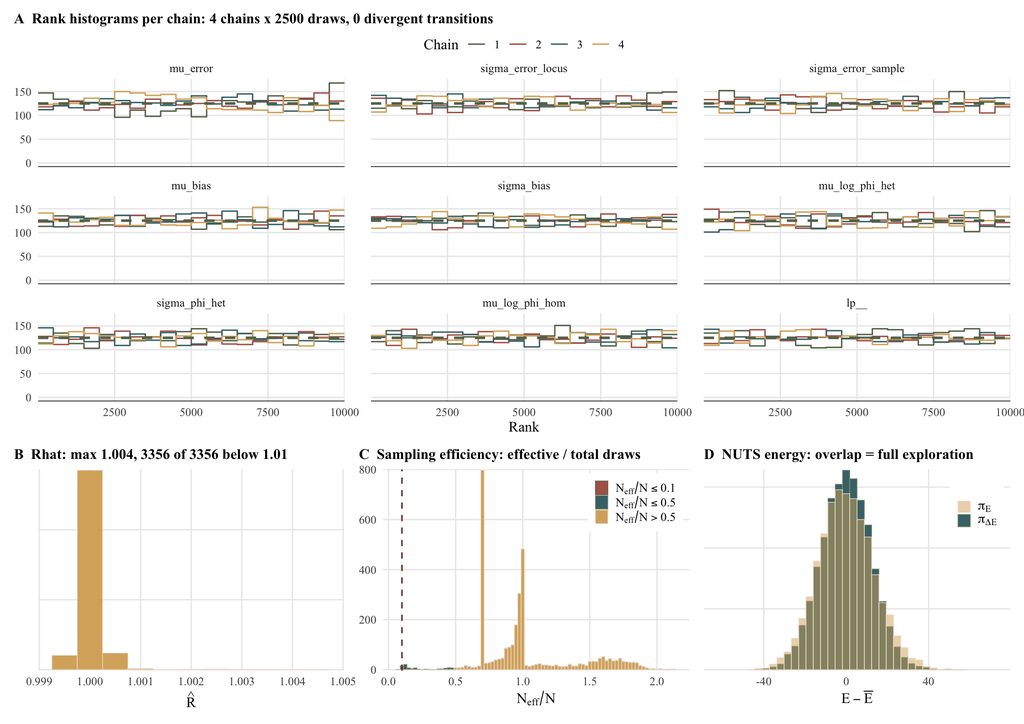

```r
### Combined diagnostics figure: chain agreement, convergence of all parameters, efficiency and exploration
diagnostics_panel_theme <- theme(plot.title = element_text(face = "bold", hjust = 0, size = 12),
                                 plot.subtitle = element_text(hjust = 0, size = 9),
                                 plot.title.position = "plot")

stan_diagnostics_panel <- wrap_plots(
  A = stan_diagnostic_plots$rank_overlay +
    scale_x_continuous(expand = c(0, 0)) +
    labs(title = sprintf("A  Rank histograms per chain: %d chains x %d draws, %d divergent transitions",
                         stan_chains, stan_iter - stan_warmup, get_num_divergent(fit_hier)),
         subtitle = NULL) +
    diagnostics_panel_theme + theme(panel.spacing.x = unit(1.5, "lines"),
                                    legend.margin = margin(0, 0, 0, 0),
                                    legend.box.spacing = unit(2, "pt")),
  B = stan_diagnostic_plots$rhat +
    labs(title = sprintf("B  Rhat: max %.3f, %d of %d below 1.01", max(rhat_hier, na.rm = TRUE),
                         sum(rhat_hier < 1.01, na.rm = TRUE), sum(is.finite(rhat_hier))),
         subtitle = NULL) +
    diagnostics_panel_theme + theme(legend.position = "none"),
  C = stan_diagnostic_plots$neff +
    geom_vline(xintercept = 0.1, linetype = "dashed", colour = "#7E4038", linewidth = 0.6) + # 0.1 = threshold
    labs(title = "C  Sampling efficiency: effective / total draws", subtitle = NULL) + diagnostics_panel_theme +
    theme(legend.text = element_text(size = 10),
          legend.key.size = unit(11, "pt"),
          legend.position = "inside",
          legend.position.inside = c(0.98, 0.98), legend.justification.inside = c(1, 1),
          legend.direction = "vertical",
          legend.background = element_rect(fill = "white", colour = NA)),
  D = mcmc_nuts_energy(nuts_hier, merge_chains = TRUE) +
    labs(title = "D  NUTS energy: overlap = full exploration", subtitle = NULL) + diagnostics_panel_theme +
    theme(legend.text = element_text(size = 11),
          legend.key.size = unit(11, "pt"),
          legend.position = "inside",
          legend.position.inside = c(0.98, 0.98), legend.justification.inside = c(1, 1),
          legend.direction = "vertical",
          legend.background = element_rect(fill = "white", colour = NA)),
  design = "AAA\nBCD", heights = c(1.6, 1))

print(stan_diagnostics_panel)
```

```r
ggsave(file.path(stan_diagnostics_folder, "diagnostics_panel.png"), stan_diagnostics_panel, width = 11.69, height = 8.27, dpi = 300, bg = "white")
ggsave(file.path(stan_diagnostics_folder, "diagnostics_panel.pdf"), stan_diagnostics_panel, width = 11.69, height = 8.27, device = cairo_pdf)
```

## 10 Stan Results Plots

This chunk contains plots for the estimated results from hierrarchical model, that is wolf ancestry and admixture per sample (results show three possible candidates, one dog and two hybrids) and two panels of estimated error rate per locus and per sample with HT overdispersion per sample. I tried to combine it with previous result, such as loci with homopolymer sites (diamonds as in previous plots for continuity), miscall per loci with crosses, red loci names showing the ones with most ties during alignment scoring and indels per read colour mapping. Maybe its a bit too much, maybe I’ll clean it up so its not too hectic.

```r
### Plots for model estimates showing error rate per locus and sample, and computed ancestry and admixture
# Importing saved .rds when only running the plots
if (!exists("fit_hier")) {
  stan_plot_inputs_file <- file.path("Results", dataset_name, "Genotypes_results", run_names$bayes_run_name, "stan_plot_inputs.rds")
  stopifnot("no saved Stan run with these settings, run the Stan model first" = file.exists(stan_plot_inputs_file))
  list2env(readRDS(stan_plot_inputs_file), envir = environment())}

phi_hom_parameter <- intersect(c("phi_hom", "mu_log_phi_hom"), fit_hier@model_pars)[1] # which phi_hom version this run used
stan_results_folder <- file.path(stan_graphics_folder, "Stan_Results_Plots")
dir.create(stan_results_folder, showWarnings = FALSE, recursive = TRUE)

# Same colour pallete as before
result_main_colour <- "#467378"
result_raw_colour <- "#8B775F"
results_theme <- theme_minimal(base_family = plot_font, base_size = 11) +
  theme(plot.title = element_text(face = "bold", hjust = 0.5),
        plot.subtitle = element_text(hjust = 0.5, size = 9),
        legend.position = "top",
        panel.grid.minor = element_blank(),
        panel.grid.major.y = element_blank())

called_class_hier <- max.col(post_hier, ties.method = "first") # called genotype of every pair

# Possible ancestry classs
ancestry_class_levels <- c("Wolf-like", "Backcross to wolf", "F1-like", "Backcross to dog", "Dog-like")
ancestry_class_colours <- setNames(c("#467378", "#D9AF6B", "#C98A4E", "#AF6458", "#7E4038"), ancestry_class_levels)

### 1. Plot, wolf ancestry per sample (only plotted when ancestry prior is used)
# Ancestry class of every sample for colouring the sample plots
sample_ancestry_class <- data.frame(sample = samples_hier, ancestry_class = factor("Wolf-like", levels = ancestry_class_levels))

if (prior_type == "ancestry") {
  # takes all the posterior draws for ancestry
  wolf_ancestry_draws <- as.matrix(fit_hier, pars = "wolf_ancestry")

  ancestry_summary <- data.frame(sample = rep(samples_hier, each = nrow(wolf_ancestry_draws)), # one row per draw and sample
                               ancestry = as.vector(wolf_ancestry_draws)) %>%
  summarise(low95 = quantile(ancestry, 0.025), low50 = quantile(ancestry, 0.25), median = median(ancestry),
            high50 = quantile(ancestry, 0.75), high95 = quantile(ancestry, 0.975), .by = sample) %>%
  mutate(ancestry_class = case_when(median >= 0.875 ~ "Wolf-like", # 1, 0.75, 0.5, 0.25, 0
                                    median >= 0.625 ~ "Backcross to wolf",
                                    median >= 0.375 ~ "F1-like",
                                    median >= 0.125 ~ "Backcross to dog",
                                    TRUE ~ "Dog-like"),
         ancestry_class = factor(ancestry_class, levels = ancestry_class_levels),
         sample = factor(sample, levels = sample[order(median)])) # plot order
  sample_ancestry_class <- transmute(ancestry_summary, sample = as.character(sample), ancestry_class)

  # Sensitivity run for Beta(0.5, 0.5) is plotted as well if it exists.
  comparison_shape <- if (ancestry_prior_shape == 1) 0.5 else 1
  comparison_run_file <- file.path("Results", dataset_name, "Genotypes_results",
                                   sub("_b[0-9.]+", paste0("_b", comparison_shape), run_names$bayes_run_name),
                                   "sample_parameters_hierarchical.tsv")
  has_comparison_run <- file.exists(comparison_run_file)
  ancestry_comparison <- if (has_comparison_run) {
    read_tsv(comparison_run_file, show_col_types = FALSE) %>%
      transmute(sample = factor(barcode, levels = levels(ancestry_summary$sample)),
                estimate = wolf_ancestry, low95 = wolf_ancestry_low, high95 = wolf_ancestry_high)
  } else data.frame(sample = factor(levels = levels(ancestry_summary$sample)), estimate = numeric(), low95 = numeric(), high95 = numeric()) # empty so nothing is drawn

  p_ancestry <- ggplot(ancestry_summary, aes(y = sample)) +
    geom_vline(xintercept = c(0.25, 0.5, 0.75), colour = "grey85", linetype = "dotted") +
    geom_vline(xintercept = 0.93, colour = "grey45", linetype = "dashed") +
    geom_linerange(data = ancestry_comparison, aes(xmin = low95, xmax = high95), colour = "grey70", linewidth = 0.6,
                   position = position_nudge(y = -0.3)) +
    geom_point(data = ancestry_comparison, aes(x = estimate), colour = "grey55", size = 1.1, shape = 4,
               position = position_nudge(y = -0.3)) + # sensitivity run below in grey
    geom_linerange(aes(xmin = low95, xmax = high95, colour = ancestry_class), linewidth = 0.6) +
    geom_linerange(aes(xmin = low50, xmax = high50, colour = ancestry_class), linewidth = 2) +
    geom_point(aes(x = median, colour = ancestry_class), size = 2.2, shape = 21, fill = "white", stroke = 1) +
    annotate("text", x = 0.925, y = 1, label = "q = 0.93\n(Harmoinen et al. 2021)", hjust = 1, size = 3,
             family = plot_font, colour = "grey35") +
    scale_colour_manual(values = ancestry_class_colours, breaks = ancestry_class_levels, name = NULL) +
    scale_x_continuous(limits = c(0, 1), breaks = seq(0, 1, 0.2), expand = expansion(mult = c(0.01, 0.02))) +
    labs(title = sprintf("Wolf ancestry per sample with 50 %% and 95 %% credible intervals for Beta(%g, %g)%s",
                         ancestry_prior_shape, ancestry_prior_shape,
                         if (has_comparison_run) sprintf("\nand grey sensitivity run Beta(%g, %g)", comparison_shape,
                            comparison_shape) else ""), x = "Wolf ancestry (0 = dog, 1 = wolf)", y = NULL) +
    results_theme + theme(legend.position = "bottom")
}

# Per sample from the reads, mean depth and number of HT calls shown in the middle column for extra data.
sample_read_summary <- data.frame(sample = samples_hier[stan_data_hier$sample_id],
                                  d = stan_data_hier$d, called = called_class_hier) %>%
  summarise(mean_depth = mean(d), n_het = sum(called == 3), .by = sample)

### 2. Plot, Eeror rate per locus coloured by indels per read, wth extra data from previous plots for contiunuity
typical_error_pct <- 100 * max_error * plogis(median(as.matrix(fit_hier, pars = "mu_error"))) # typical error %

# Read-leve table from the 06a for homopolymer detection
locus_qc_file <- file.path("Results", dataset_name, "Graphics", "Demultiplexing_and_Filtration_Visualization", "locus_indel_homopolymer_summary.tsv")
locus_qc <- if (file.exists(locus_qc_file)) {
  read_tsv(locus_qc_file, show_col_types = FALSE) %>% select(locus, tie, indel_raw, hp_len_primer)
} else data.frame(locus = loci_hier, tie = NA_real_, indel_raw = NA_real_, hp_len_primer = NA_real_)

# Observed error, share of minor allele frequency in HM pairs
raw_error_by_locus <- data.frame(locus = loci_hier[stan_data_hier$locus_id], k = stan_data_hier$k, d = stan_data_hier$d, called = called_class_hier) %>%
  filter(called != 3) %>% # HM only
  summarise(raw_error = 100 * sum(ifelse(called == 1, d - k, k)) / sum(d), .by = locus) # wrong-allele votes / all votes

# Stan genotype calls that differ from the reference genotype
reference_genotypes_plot <- read_tsv(file.path("Data/Supporting_data/Reference_genotypes", paste0("genotypes_", dataset_name, ".tsv")), show_col_types = FALSE, col_types = cols(.default = col_character()))

stan_miscalls <- combined_genotypes_hier %>%
  select(barcode, locus, depth, GQ, genotype_stan) %>%
  inner_join(select(reference_genotypes_plot, barcode = sample_id, locus, reference = genotype), by = c("barcode", "locus")) %>%
  filter(!is.na(genotype_stan), !is.na(reference),
         genotype_stan != reference, # differs as written or swapped letters
         genotype_stan != paste0(substr(reference, 2, 2), substr(reference, 1, 1))) %>%
  arrange(locus, barcode)

kable(stan_miscalls, col.names = c("Sample", "Locus", "Depth", "GQ", "Stan call", "Reference"))
```

| Sample | Locus | Depth | GQ | Stan call | Reference |
| --- | --- | --- | --- | --- | --- |
| W215207.r1 | BICF2P223300 | 7 | 41.2 | CT | CC |
| W215208.r1 | BICF2P223300 | 10 | 77.7 | CT | CC |
| W215214 | BICF2P57528 | 13 | 12.9 | CT | CC |
| W215220 | BICF2P878735 | 3 | 3.2 | AG | GG |
| W215214.r1 | BICF2S2305942 | 9 | 35.0 | GT | GG |

```r
error_locus_summary <- data.frame(locus = rep(loci_hier, each = nrow(draws_hier$error_locus)),
                                  error = 100 * as.vector(draws_hier$error_locus)) %>%
  summarise(low95 = quantile(error, 0.025), low50 = quantile(error, 0.25), median = median(error),
            high50 = quantile(error, 0.75), high95 = quantile(error, 0.975), .by = locus) %>%
  left_join(locus_qc, by = "locus") %>%
  left_join(raw_error_by_locus, by = "locus") %>%
  left_join(count(stan_miscalls, locus, name = "n_miscalls"), by = "locus") %>%
  mutate(high_ties = rank(-tie, na.last = "keep") <= 3, # the three loci with the most ties from 06
         primer_homopolymer = hp_len_primer >= 5, # sae diamonds to show them
         locus = sub("_rs\\d+$", "", locus), # shorter TIGRP locus names for TIGR loci
         locus = factor(locus, levels = locus[order(median)]))

locus_marks <- c("Observed error" = 16, "Miscall vs reference" = 4, "Primer homopolymer \u2265 5 nt" = 18) # dot, x and diamond

p_error_locus <- ggplot(error_locus_summary, aes(y = locus)) +
  geom_vline(xintercept = typical_error_pct, colour = "grey40", linetype = "dashed") +
  annotate("text", x = typical_error_pct, y = Inf, vjust = -0.5, size = 3, family = plot_font, colour = "grey30",
           label = sprintf("Typical error: %.2f %%", typical_error_pct)) +
  geom_linerange(aes(xmin = low95, xmax = high95, colour = indel_raw), linewidth = 0.5) +
  geom_linerange(aes(xmin = low50, xmax = high50, colour = indel_raw), linewidth = 1.6) +
  geom_point(aes(x = median, colour = indel_raw), shape = 21, fill = "white", size = 2, stroke = 0.9) +
  geom_point(aes(x = raw_error, shape = "Observed error"), colour = "grey45", size = 1.3) + # observed share
  geom_point(data = filter(error_locus_summary, n_miscalls > 0), aes(x = ifelse(primer_homopolymer %in% TRUE, 0.07, 0), shape = "Miscall vs reference"), colour = "grey10", size = 2, stroke = 1) +
  geom_point(data = filter(error_locus_summary, primer_homopolymer %in% TRUE), aes(x = 0, shape = "Primer homopolymer \u2265 5 nt"),
             size = 3, colour = "grey20") + # diamond at the left edge
  geom_text(aes(x = -Inf, label = paste0(locus, "  ")), hjust = 1, size = 7.5 / .pt, family = "mono",
            colour = ifelse(error_locus_summary$high_ties %in% TRUE, "#AF6458", "grey30"),
            fontface = ifelse(error_locus_summary$high_ties %in% TRUE, "bold", "plain")) +
  scale_colour_gradientn(colours = c("#E6CBC1", "#C98A7E", "#AF6458", "#7E4038"), # colour gradient for indels
                         na.value = result_main_colour, name = "Indels per read") +
  scale_shape_manual(values = locus_marks, breaks = names(locus_marks), name = NULL) +
  coord_cartesian(clip = "off") +
  guides(colour = guide_colourbar(order = 1, title.position = "left", title.vjust = 1, barwidth = unit(3, "cm"), barheight = unit(0.3, "cm")), shape = guide_legend(order = 2, keyheight = unit(0.3, "cm"), override.aes = list(size = c(1.6, 2, 3), colour = c("grey45", "grey10", "grey20")))) +
  labs(title = "Sequencing error rate per locus for a typical sample", x = "Error rate (%)", y = NULL) +
  results_theme +
  theme(legend.position = "bottom",
        legend.box.just = "top", legend.spacing.x = unit(10, "pt"),
        legend.justification = "center", legend.location = "plot",
        plot.title = element_text(face = "bold", hjust = 0.5, margin = margin(b = 14)),
        axis.text.y = element_text(family = "mono", size = 7.5, colour = "transparent"),
        legend.title = element_text(size = 10), legend.text = element_text(size = 10))

### 3. Overdispersion per sample, as effective number sample size in a HT
phi_het_sample_summary <- data.frame(sample = rep(samples_hier, each = nrow(draws_hier$phi_het_sample)),
                                     effective_size = as.vector(draws_hier$phi_het_sample) + 1) %>% #effective sample size
  summarise(low95 = quantile(effective_size, 0.025), low50 = quantile(effective_size, 0.25), median = median(effective_size),
            high50 = quantile(effective_size, 0.75), high95 = quantile(effective_size, 0.975), .by = sample) %>%
  left_join(sample_ancestry_class, by = "sample") %>%
  mutate(sample = factor(sample, levels = sample[order(median)]))

p_phi_het_sample <- ggplot(phi_het_sample_summary, aes(y = sample, colour = ancestry_class)) +
  geom_vline(xintercept = median(draws_hier$phi_het) + 1, colour = "grey40", linetype = "dashed") +
  annotate("text", x = median(draws_hier$phi_het) + 1, y = Inf, vjust = -0.5, size = 3, family = plot_font, colour = "grey30",
           label = sprintf("Typical sample: %.0f", median(draws_hier$phi_het) + 1)) +
  coord_cartesian(clip = "off") +
  geom_linerange(aes(xmin = low95, xmax = high95), linewidth = 0.5) +
  geom_linerange(aes(xmin = low50, xmax = high50), linewidth = 1.6) +
  geom_point(aes(x = median), shape = 21, fill = "white", size = 2, stroke = 0.9) +
  scale_colour_manual(values = ancestry_class_colours, breaks = ancestry_class_levels, name = NULL) +
  labs(title = "B  Effective sample size of the HT read split per sample",
       x = "Effective sample size (higher = closer to binomial)", y = NULL) +
  results_theme


### 4. Error rate per sample
error_sample_summary <- data.frame(sample = rep(samples_hier, each = nrow(draws_hier$error_sample)),
                                   error = 100 * as.vector(draws_hier$error_sample)) %>% # in %
  summarise(low95 = quantile(error, 0.025), low50 = quantile(error, 0.25), median = median(error),
            high50 = quantile(error, 0.75), high95 = quantile(error, 0.975), .by = sample) %>%
  left_join(sample_ancestry_class, by = "sample") %>%
  left_join(sample_read_summary, by = "sample") %>% # mean depth and HT calls for the middle column showin gmore data
  mutate(sample = factor(sample, levels = sample[order(median)]))

p_error_sample <- ggplot(error_sample_summary, aes(y = sample, colour = ancestry_class)) +
  geom_vline(xintercept = typical_error_pct, colour = "grey40", linetype = "dashed") +
  annotate("text", x = typical_error_pct, y = Inf, vjust = -0.5, size = 3, family = plot_font, colour = "grey30",
           label = sprintf("Typical error: %.2f %%", typical_error_pct)) +
  coord_cartesian(clip = "off") +
  geom_linerange(aes(xmin = low95, xmax = high95), linewidth = 0.5) +
  geom_linerange(aes(xmin = low50, xmax = high50), linewidth = 1.6) +
  geom_point(aes(x = median), shape = 21, fill = "white", size = 2, stroke = 0.9) +
  scale_colour_manual(values = ancestry_class_colours, breaks = ancestry_class_levels, name = NULL) +
  labs(title = "A  Sequencing error rate per sample with locus effect set to average",
       x = "Error rate (%)", y = NULL) +
  results_theme
```

```r
### Combined panel for sample error rate and overdispersion with middle column
sample_panel_theme <- theme(plot.title = element_text(face = "bold", hjust = 0, size = 12),
                            plot.subtitle = element_text(hjust = 0, size = 9, margin = margin(b = 14)),
                            plot.title.position = "plot")
sample_panel_order <- levels(error_sample_summary$sample) # sorted by error rate used by all

# Middle column made for small heatmap, values from 0-1
sample_counts_data <- error_sample_summary %>%
  mutate(depth_fill = rescale(mean_depth), het_fill = rescale(n_het))

p_sample_counts <- ggplot(sample_counts_data, aes(y = sample)) +
  geom_tile(aes(x = 1, fill = depth_fill), width = 1, height = 1, colour = "black", linewidth = 0.2) +
  geom_tile(aes(x = 2, fill = het_fill), width = 1, height = 1, colour = "black", linewidth = 0.2) +
  geom_text(aes(x = 1, label = comma(round(mean_depth)), colour = depth_fill > 0.6), size = 2.3, family = plot_font) +
  geom_text(aes(x = 2, label = n_het, colour = het_fill > 0.6), size = 2.3, family = plot_font) +
  scale_fill_gradientn(colours = c("#F1E4DB", "#D9AF6B", "#C98A4E", "#7E4038"), guide = "none") +
  scale_colour_manual(values = c(`FALSE` = "grey15", `TRUE` = "white"), guide = "none") +
  scale_x_continuous(breaks = c(1, 2), labels = c("Mean\nreads", "HT\ncalls"), limits = c(0.5, 2.5), position = "top") +
  labs(x = NULL, y = NULL) +
  theme_void(base_family = plot_font) +
  theme(axis.text.x.top = element_text(face = "bold", size = 7, lineheight = 0.9, colour = "grey15"))

  # Combines into panel
p_sample_quality_panel <- wrap_plots(p_error_sample + sample_panel_theme,p_sample_counts,
                                     p_phi_het_sample + scale_y_discrete(limits = sample_panel_order) + sample_panel_theme + theme(axis.text.y = element_blank()), nrow = 1, widths = c(4, 0.45, 4), guides = "collect") & theme(legend.position = "bottom")

###  5. plot, wolf ancestry against the share of HT calls over all loci, with plotted expected share of HT loci for every specifi qvalue if the popualtion was free mixing over mulitple generations.

if (prior_type == "ancestry") {
  wolf_frequency <- stan_data_hier$p_wolf
  dog_frequency <- stan_data_hier$p_dog

  # Observed share of HT calls for every sample over all the 33 loci
  triangle_samples <- data.frame(sample = samples_hier[stan_data_hier$sample_id], het = called_class_hier == 3) %>% # finds HT
    summarise(heterozygosity = mean(het), .by = sample) %>% #share of HT per sample
    left_join(transmute(ancestry_summary, sample = as.character(sample), median, low95, high95, ancestry_class), by = "sample")

  # Calculates expected share of HT for each type
  f1_gamete <- (wolf_frequency + dog_frequency) / 2 # allele 1 probability in F1
  cross_reference <- data.frame(
    cross = c("Wolf", "Backcross to wolf", "F1", "Backcross to dog", "Dog"),
    ancestry = c(1, 0.75, 0.5, 0.25, 0),
    heterozygosity = c(mean(2 * wolf_frequency * (1 - wolf_frequency)), # wolf
                       mean(wolf_frequency * (1 - f1_gamete) + f1_gamete * (1 - wolf_frequency)),
                       mean(wolf_frequency * (1 - dog_frequency) + dog_frequency * (1 - wolf_frequency)),
                       mean(dog_frequency * (1 - f1_gamete) + f1_gamete * (1 - dog_frequency)),
                       mean(2 * dog_frequency * (1 - dog_frequency)))) # Dog

  #Calculation for late generation hybrids in admixed population, share of HT for every possible q value, draws the dashed curved line
  admixed_curve <- data.frame(ancestry = seq(0, 1, 0.01)) %>%
    mutate(heterozygosity = sapply(ancestry, function(q)
      mean(2 * (q * wolf_frequency + (1 - q) * dog_frequency) * (1 - (q * wolf_frequency + (1 - q) * dog_frequency)))))

  mark_items <- c("Expected cross", "Later generations")

  p_ancestry_HT <- ggplot() +
    geom_line(data = admixed_curve, aes(x = ancestry, y = heterozygosity, linetype = "Later generations"), colour = "grey60") +
    geom_point(data = cross_reference, aes(x = ancestry, y = heterozygosity, shape = "Expected cross"),
               size = 3.5, colour = "grey30", fill = "white") +
    geom_text(data = cross_reference, aes(x = ancestry, y = heterozygosity, label = cross), vjust = -1.1, size = 3,
              family = plot_font, colour = "grey30") +
    geom_errorbar(data = triangle_samples, aes(y = heterozygosity, xmin = low95, xmax = high95, colour = ancestry_class),
                  orientation = "y", width = 0, linewidth = 0.4, alpha = 0.7) +
    geom_point(data = triangle_samples, aes(x = median, y = heterozygosity, colour = ancestry_class), size = 2.6) +
    geom_text(data = filter(triangle_samples, ancestry_class != "Wolf-like"), aes(x = median, y = heterozygosity, label = sample),
              hjust = -0.15, vjust = 1.4, size = 3, family = plot_font) +
    scale_colour_manual(values = ancestry_class_colours, breaks = ancestry_class_levels, name = NULL) +
    scale_shape_manual(values = c(23, NA), breaks = mark_items, limits = mark_items, name = NULL) +
    scale_linetype_manual(values = c("blank", "dashed"), breaks = mark_items, limits = mark_items, name = NULL) + #dashed for the line
    scale_x_continuous(limits = c(0, 1), breaks = seq(0, 1, 0.25)) +
    scale_y_continuous(limits = c(0, NA), expand = expansion(mult = c(0, 0.12))) +
    guides(colour = guide_legend(order = 1), shape = guide_legend(order = 2), linetype = guide_legend(order = 2)) +
  labs(title = sprintf("Ancestry against heterozygosity, %d loci (median and 95 %% interval)", length(wolf_frequency)),
         x = "Wolf ancestry", y = "Share of HT calls") +
    results_theme +
    theme(legend.position = "bottom", legend.box = "horizontal", legend.spacing.x = unit(3, "pt"),
      legend.text = element_text(size = 8, margin = margin(l = 2, r = 6)), legend.key.width = unit(12, "pt"),
      legend.key.height = unit(10, "pt"), legend.box.spacing = unit(4, "pt"), panel.grid.major.y = element_line(colour = "grey92"))
}


### 7. Plot showing genotypes results with  allele 1 read share against depth, with call boundaries for every sample pair with a flat prior. coloured by GQ
```

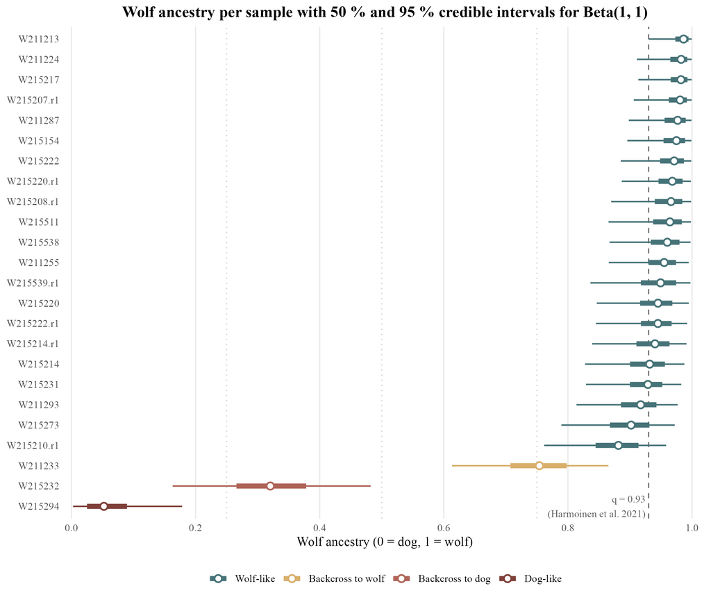

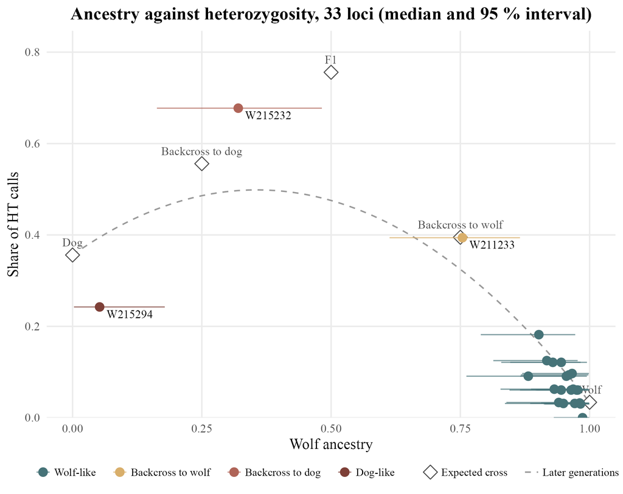

```r
# Gets median error, allele bias and overdispersion from the fitted model for the typical pair used for the boundaries
typical_error <- typical_error_pct / 100
typical_het_fraction <- stan_data_hier$het_min + (1 - 2 * stan_data_hier$het_min) * plogis(median(as.matrix(fit_hier, pars = "mu_bias")))
typical_phi_het <- median(draws_hier$phi_het)
typical_phi_hom <- if (phi_hom_parameter == "phi_hom") median(as.matrix(fit_hier, pars = "phi_hom")) else 10 + exp(median(as.matrix(fit_hier, pars = "mu_log_phi_hom")))
typical_p_het <- typical_het_fraction * (1 - typical_error) + (1 - typical_het_fraction) * typical_error

# where the boundaries are calculated
genotype_depths <- unique(c(3:100, round(10^seq(2, log10(max(stan_data_hier$d)), length.out = 60))))

# Expected allele 1 share (p) and overdispersion (phi) of each genotype
genotype_models <- data.frame(genotype = c("HM allele 1", "HT", "HM allele 2"),
                              p = c(1 - typical_error, typical_p_het, typical_error),
                              phi = c(typical_phi_hom, typical_phi_het, typical_phi_hom))

# For every depth and allele 1 count computes the genotype with the highest beta-binomial likelihood
call_boundaries <- data.frame(d = genotype_depths) %>%
  reframe(k = 0:d, .by = d) %>% # every possible allele 1 count at every depth
  cross_join(genotype_models) %>% # once per genotype
  mutate(log_likelihood = lbeta(k + p * phi, d - k + (1 - p) * phi) - lbeta(p * phi, (1 - p) * phi)) %>%
  filter(log_likelihood == max(log_likelihood), .by = c(d, k)) %>% #keeps the best one
  filter(genotype == "HT") %>%
  summarise(het_low = min(k) - 0.5, het_high = max(k) + 0.5, .by = d) # midway point for calls on boundaries

genotype_cloud <- data.frame(allele1_reads = stan_data_hier$k, allele2_reads = stan_data_hier$d - stan_data_hier$k,
                             called = factor(c("HM allele 1", "HM allele 2", "HT")[called_class_hier],
                                             levels = c("HM allele 1", "HT", "HM allele 2")),
                             confident = stan_rows_hier$GQ >= 20)
read_breaks <- c(0, 1, 10, 100, 1000, 10000)

p_genotypes_plot <- ggplot(genotype_cloud, aes(x = allele2_reads + 1, y = allele1_reads + 1)) +
  geom_path(data = call_boundaries, aes(x = d - het_low + 1, y = het_low + 1), colour = result_raw_colour, linetype = "dashed", inherit.aes = FALSE) +
  geom_path(data = call_boundaries, aes(x = d - het_high + 1, y = het_high + 1), colour = result_raw_colour, linetype = "dashed", inherit.aes = FALSE) +
  geom_point(aes(colour = called, shape = confident), size = 1.4, alpha = 0.8, stroke = 0.7) +
  scale_colour_manual(values = c("HM allele 1" = "#476F84", "HT" = "#A4552A", "HM allele 2" = "#A4BED5"), name = NULL) +
  scale_shape_manual(values = c(`TRUE` = 16, `FALSE` = 1), labels = c(`TRUE` = "GQ >= 20", `FALSE` = "GQ < 20"), name = NULL) +
  scale_x_log10(breaks = read_breaks + 1, labels = label_comma()(read_breaks)) +
  scale_y_log10(breaks = read_breaks + 1, labels = label_comma()(read_breaks)) +
  coord_equal() +
  guides(colour = guide_legend(order = 1, override.aes = list(shape = 16, size = 2.5, alpha = 1)),
         shape = guide_legend(order = 2, override.aes = list(size = 2.5, colour = "grey20"))) +
  labs(title = "Allele 1 reads against allele 2 reads with call boundary for typical pair with a flat prior",
       x = "Allele 2 reads (log scale)", y = "Allele 1 reads (log scale)") +
  results_theme +
  theme(panel.grid.major.y = element_line(colour = "grey92"), panel.grid.major.x = element_line(colour = "grey92"),
                        plot.title = element_text(size = 11), plot.title.position = "plot",
                        legend.position = "right", legend.spacing.y = unit(4, "pt"))

### Saving plots, ancestry plots only when they exist
if (prior_type == "ancestry") {
  ggsave(file.path(stan_results_folder, "results_ancestry.png"), p_ancestry, width = 8.27, height = 7, dpi = 300, bg = "white")
  ggsave(file.path(stan_results_folder, "results_ancestry.pdf"), p_ancestry, width = 8.27, height = 7, device = cairo_pdf)
  ggsave(file.path(stan_results_folder, "results_ancestry_HT.png"), p_ancestry_HT, width = 16, height = 12.7, units = "cm", dpi = 300, bg = "white")
  ggsave(file.path(stan_results_folder, "results_ancestry_HT.pdf"), p_ancestry_HT, width = 16, height = 12.7, units = "cm", device = cairo_pdf)
include_graphics(normalizePath(file.path(stan_results_folder, c("results_ancestry.png", "results_ancestry_HT.png"))), rel_path = FALSE, error = FALSE)
}
```

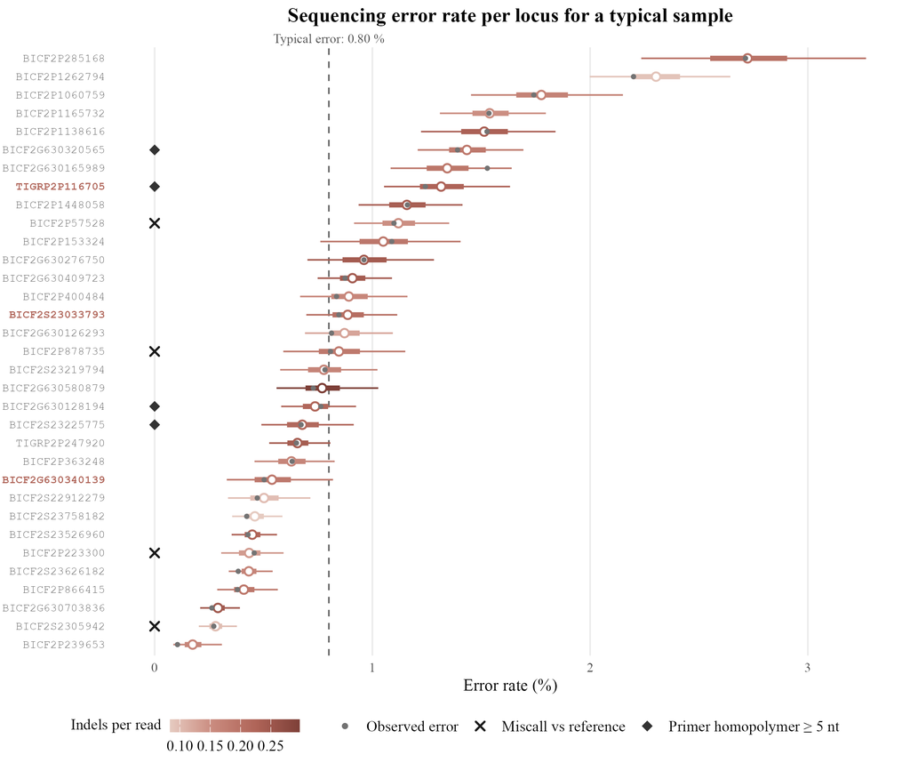

```r
ggsave(file.path(stan_results_folder, "results_errorrate_locus.png"), p_error_locus, width = 8.27, height = 7, dpi = 300, bg = "white")
ggsave(file.path(stan_results_folder, "results_errorrate_locus.pdf"), p_error_locus, width = 8.27, height = 7, device = cairo_pdf)
include_graphics(normalizePath(file.path(stan_results_folder, "results_errorrate_locus.png")), rel_path = FALSE, error = FALSE)
```

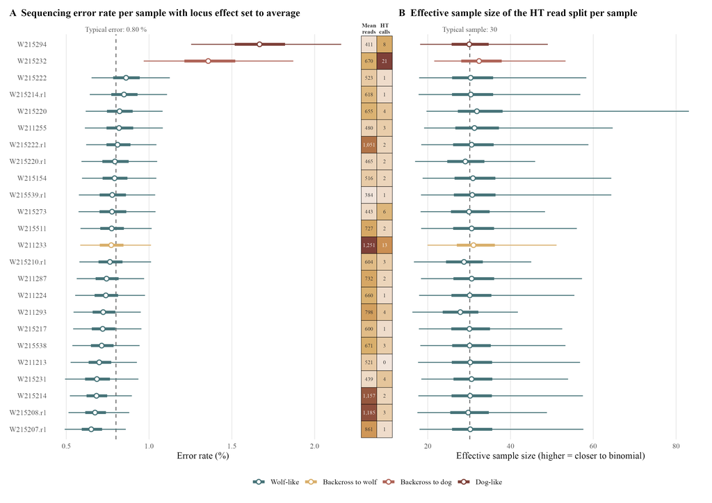

```r
ggsave(file.path(stan_results_folder, "results_sample_quality_panel.png"), p_sample_quality_panel, width = 11.69, height = 8.27, dpi = 300, bg = "white")
ggsave(file.path(stan_results_folder, "results_sample_quality_panel.pdf"), p_sample_quality_panel, width = 11.69, height = 8.27, device = cairo_pdf)
include_graphics(normalizePath(file.path(stan_results_folder, "results_sample_quality_panel.png")), rel_path = FALSE, error = FALSE)
```

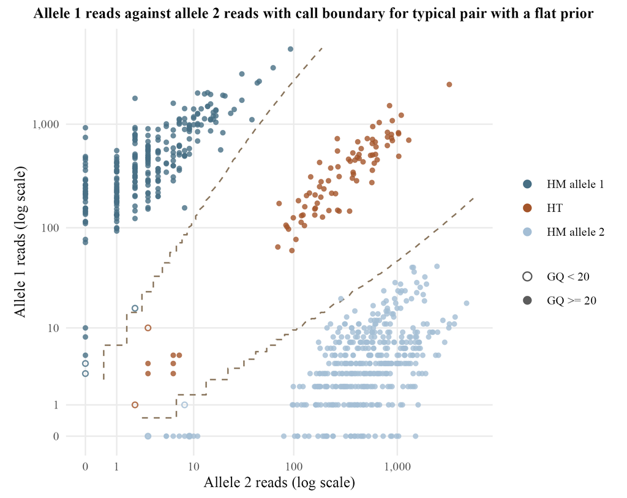

```r
ggsave(file.path(stan_results_folder, "results_genotypes.png"), p_genotypes_plot, width = 16, height = 12.7, units = "cm", dpi = 300, bg = "white")
ggsave(file.path(stan_results_folder, "results_genotypes.pdf"), p_genotypes_plot, width = 16, height = 12.7, units = "cm", device = cairo_pdf)
include_graphics(normalizePath(file.path(stan_results_folder, "results_genotypes.png")), rel_path = FALSE, error = FALSE)
```

**Settings used for this run**

| Setting | Value |
| --- | --- |
| run_date | 2026-11-06 19:23 |
| dataset_name | big |
| n_barcodes | 24 |
| primer_panel_path | Data/Supporting_data/Primer_panels/12864_2021_7761_MOESM12_ESM_filtered.xlsx |
| reference_path | Data/Supporting_data/Genome_reference_data/snps_500bp_sequences.fa |
| input_type | unpadded |
| use_anchors | TRUE |
| anchor_length | 3 |
| probe_type | asp_primers |
| threshold_type | errors |
| min_score_fraction | 0.65 |
| error_rate | 0.08 |
| strand_downgrade | FALSE |
| prior_type | ancestry |
| prior_het_share | 0.15 |
| prior_population | FreqWOLF_EastEurope |
| prior_floor | 0.001 |
| ancestry_prior_shape | 1 |
| phi_hom_structure | shared |
| stan_iter | 4000 |
| stan_warmup | 1500 |
| stan_chains | 4 |
| max_error | 0.1 |
| read_depths_to_test | 3, 4, 5, 6, 7, 8, 10, 12, 15, 20, 25, 30, 40, 50, 60, 75 |
| draws_per_depth | 300 |
| minimum_reads_for_truth_pair | 75 |
| bootstrap_rounds | 1000 |